# Final Project

Haley Vien, Cathlyn Liang, Tara Mercene, Maria Arreola

12/3/2019

# The Data

The data we will be using is *hiphop_cand_lyrics* from the *fivethirtyeight* package. This data represents hiphop songs that referenced POTUS candidates in 2016. There are 377 rows of data and 8 variables. The 8 variables are the *candidate* referenced, the *song* name, the *artist*, the *sentiment* of the lyric, the *theme* of the lyric, the *album_release_date*, the *line* referencing the candidate, and the *url* to the song. This data was collected from [Genius](https://genius.com/).

Note: For themes, one of the values is NA which represents misc. themes.

Note 2: The references were classified as negative, positive, and neutral by a group of FiveThirtyEight staffers who were interested in hip-hop and quantifying things. If there was a reference that obviously fit into one category, the lead researcher, Allison McCann, would classify it. Additionally, if there was a a trickier reference that was hard to decipher, three people, senior editor Chadwick Matlin, intern Setrige Crawford and McCann, would make the final decision after deliberation.

# Research Question

When looking at Hillary Clinton and Donald Trump’s mentions in hip hop songs, does the relation between candidate and sentiment differ between the two and does that change over time?

Our response variable is sentiment while our explanatory variables are candidate and the album’s release date.

# Graphing the Data

Note: *hiphop_hcdt* is *hiphop_cand_lyrics* but it has been filtered to only show the results of Donald Trump and Hillary Clinton and is the data we will be using from now on. For some of the graphs we also use *hiphop_hc* which is the original data filtered to only include Hillary Clinton’s results and *hiphop_dt* does the same but filters for Donald Trump’s results.

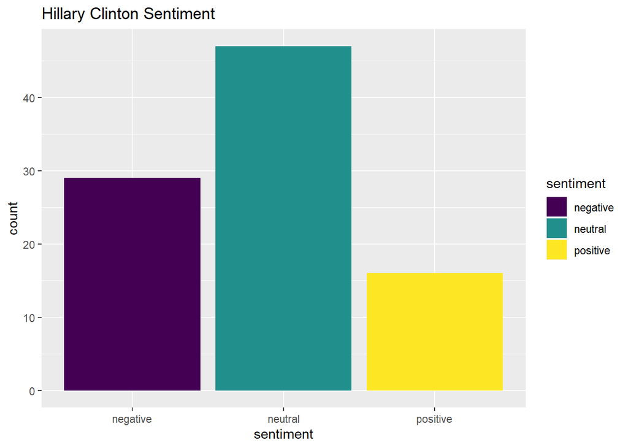

For Hillary Clinton, neutral sentiment ranks first (46-47), followed by negative (28-29) and positive sentiment (16).

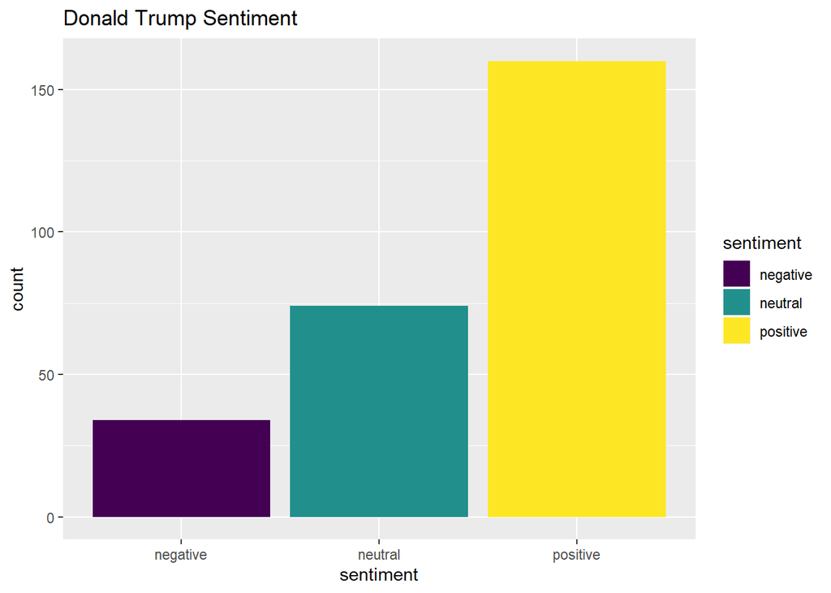

Donald Trump has more positive sentiment references in songs than Hillary Clinton (and overall more references in songs). Proportionally, his positive sentiment references has a significantly larger count than his neutral and negative sentiment references.

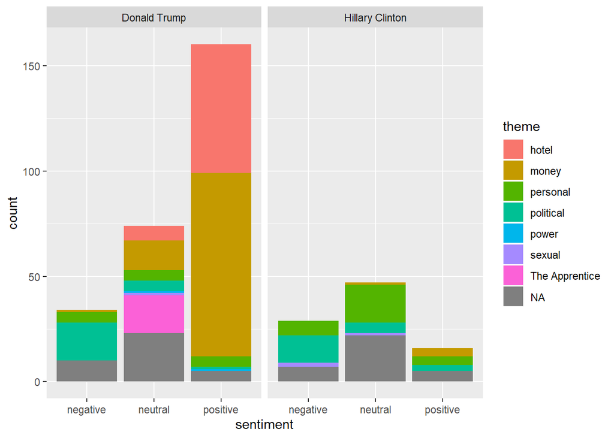

The graph above shows the sentiment of the songs that mention Donald Trump or Hillary Clinton and is filled with the theme of the mentioned lyric.

Interestingly enough, when analyzing the positive bar for Donald Trump inside of this graph, most of the lyrics that mention him in a positive *sentiment* are related to Trump’s hotel and money. The amount of times artists refer to these 2 themes almost quadruples the amount of times Trump is referred to negatively. When looking at the negative bar, most of the negative references are related to the political theme.

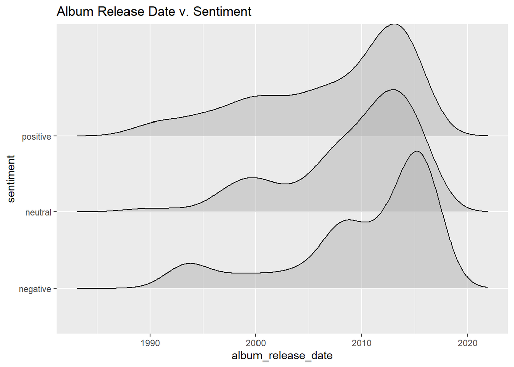

Increase in all sentiments. Positive and neutral sentiment peak at around 2013 whereas negative sentiment peaks later (at around 2015).

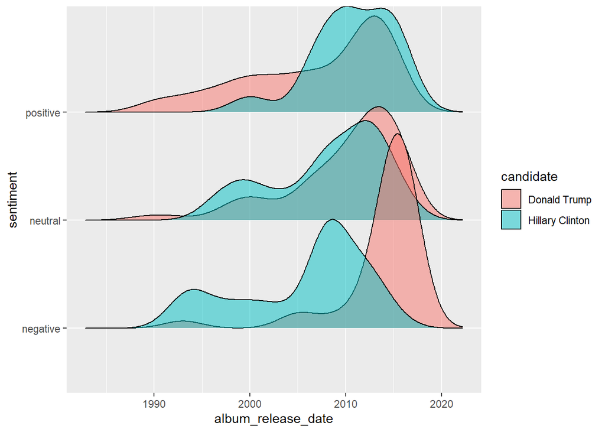

The above graph showcases how the *sentiment* towards Donald Trump and Hillary Clinton have changed over time in reference to the *album_release_date* of songs that reference them.

Between 2010 and 2020, the negative *sentiment* towards Donald Trump drastically increases and even peaks at around 2016, right around when he was running for presidency. For Clinton, negative references to her in hiphop songs suddenly increased in 2005 and peaked right before 2010, then it linearly decreased, almost having no negative references in 2016.

# Hypothesis Tests

| term | estimate | std.error | statistic | p.value |
| --- | --- | --- | --- | --- |
| (Intercept) | -1.928961 | 0.1835349 | -10.510046 | 7.765541e-26 |
| candidateHillary Clinton | 1.153122 | 0.2898979 | 3.977682 | 6.959045e-05 |

The hypotheses that we are testing for the model *glm.cand* which only looks at the relationship between *candidate* and *sentiment_negative* are:

$$H_0: \beta_1 = 0 \\
H_1: \beta_1 \ne 0$$
$H_0$ is the hypothesis that there is no relationship between *sentiment_negative* and *candidate*.

$H_1$ is the hypothesis that there is a relationship between *sentiment_negative* and *candidate.

| term | estimate | std.error | statistic | p.value |
| --- | --- | --- | --- | --- |
| (Intercept) | -120.62806811 | 50.54353119 | -2.386617 | 1.700418e-02 |
| candidateHillary Clinton | 1.23961568 | 0.29683269 | 4.176143 | 2.964938e-05 |
| album_release_date | 0.05906545 | 0.02513923 | 2.349533 | 1.879698e-02 |

Since the p-value for *album_release_date* is 0.02, which is less than 0.05, then we can reject the null hypothesis $H_0$. This shows that there is a relationship between *album_release_date* and *sentiment_negative*.

# Fitting models

Note: *glm.cand* and *glm.cand.date* are our models that we will use to predict for negative *sentiment*. Neutral and positive *sentiment* are grouped together to make interpreting the model simpler.

| term | estimate | exp_est |
| --- | --- | --- |
| (Intercept) | -1.928961 | 0.1452991 |
| candidateHillary Clinton | 1.153122 | 3.1680672 |

The exponentiated estimate for the intercept, 0.15, represents the odds of Trump being referenced in a negative sentiment.

The exponentiated estimate for *candidateHillaryClinton* means that the odds of getting a negative sentiment for Hillary Clinton is 3.16 times the odds of getting a negative sentiment for Donald Trump.

| term | estimate | exp_est |
| --- | --- | --- |
| (Intercept) | -120.62806811 | 4.091623e-53 |
| candidateHillary Clinton | 1.23961568 | 3.454286e+00 |
| album_release_date | 0.05906545 | 1.060845e+00 |

In this model, we are accounting for *album_release_date* as well as *candidate* whereas in the previous model, we are only accounting for *candidate*.

After accounting for *album_release_date*, the exponentiated estimate for *candidateHillaryClinton* represents that the odds of Hillary Clinton having negative sentiment is 3.45 times the odds of Donald Trump having negative sentiment.

The *album_release_date*’s exponentiated estimate means that as *album_release_date* increases by one unit, the odds of having a negative sentiment is multiplied by 1.06.

This seems like a better model because the *candidates*’ *sentiment* changes every year as new albums are released.

# Summary of What We’ve Learned

**Research Question Answer**

From the graphs and models above, it is clear that the *candidate* does have an effect on *sentiment* and that is shown through the barplots above. It is also clear that *album_release_date* also has an effect on *sentiment*. This can be seen more through our ggridges plot.

**Why Is This Interesting?**

Throughout our research we have seen how politics affects pop culture, specifically with these two candidates. Especially with the new presidential election coming up in 2020, it will be interesting to observe how current POTUS candidates will affect the hip hop songs coming out in the next year or so.

**Pitfalls**

1. The references that were considered to Hillary Clinton were not specifically about her but they also included references to her family (ex: Bill Clinton) while for Trump, it was more geared directly towards him and his brand.
2. Having to deal with more subjective data since *sentiment* was determined on “hip hop experts” opinions.
3. The original data set begins tracing songs from 1989 to 2016.